# Workshop 11

Carlos Daboín

2022-07-07

# **Modelos de clasificación**

Hay muchísimos problemas para los cuales nos pueden servir los modelos de clasificación. Algunos ejemplos son:

- Prestación de crédito: ¿Cómo saber quíenes me van a pagar?
- Probabilidad de salirse del servicio: ¿Cómo a que cliente llamar para ofrecerle un descuento?
- Probabilidad de recibir algún tratamiento (Les suena familiar?)
- etc.

## Intro: Mi primer trabajo

En el año 2018 una serie de eventos fortuitos me llevaron hasta [Nosis Investigación y Desarrollo SA](https://www.nosis.com/es), una empresa de técnología e información que presta servicio a instituciones financieras desde hace más de 20 años, y que en los últimos años se ha especializado a brindar consultorías sobre Big Data.

La principal tarea del equipo al que pertenecía era desarrollar nuevas y mejores versiones del Score Nosis, una de las piezas de información mas valiosa de la compañía.

**¿Alguno ha escuchado algo sobre scores crediticios?**

En términos generales, es un número que indica a los bancos que probabilidad tienes de pagarles el crédito que les estás por perdir. Así es cómo funcionaba el proceso de desarrollo:

- Teníamos datos longitudinales con el comportamiento crediticio de varios clientes del sector financiero.
- Estos datos longitudinales se transformaban en un cross-section a nivel individuo.
- Incluían un flag, que indicaba si la persona había incurrido en un cese de pagos en ese período o no.
- Los datos incluían un set de co-variables (edad, género, si es empleado o autónomo, etc) ¿A que período creen que correspondían esas co-variables?.
- Se identifican las co-variables son mas efectivas prediciendo el cese de pagos. Acá estaba la parte pesada del trabajo: Teníamos cientos de variables, distintos tipos de individuos en la base de datos, y una que otra restriccion impuesta por el Banco Central de La República de Argentina (BCRA).
- Este modelo se fijaba con una regresión logistica. Tras fijarse el modelo, se producía una predicción de la probabilidad de cese de pagos. Esta predicción se invertia, y después se multiplicaba por 1000 para que fuera mas interpretable y listo, ahí ya teníamos un producto para venderle a nuestros clientes (en realidad no terminaba allí, pero esto es lo relevante para el tema de hoy).

Repasemos un típoco proceso de modelado de score con datos ficticios:

```r
default<-read_csv("data/Default.csv")
```

```
## * `` -> ...1
```

```r
# Un vistazo rapido a los datos.
head(default)
```

```
## # A tibble: 6 x 5
##    ...1 default student balance income
##   <dbl> <chr>   <chr>     <dbl>  <dbl>
## 1     1 No      No         730. 44362.
## 2     2 No      Yes        817. 12106.
## 3     3 No      No        1074. 31767.
## 4     4 No      No         529. 35704.
## 5     5 No      No         786. 38463.
## 6     6 No      Yes        920.  7492.
```

```r
# Corrijamos el formato de las variables binarias
default<-default %>%
  mutate(bdefault=ifelse(default=="Yes",1,0),
         bstudent=ifelse(student=="Yes",1,0))
```

```r
# Dividir entre entrenamiento y evaluación
# usamos el paquete rsample para hacer una division 70% training -30% testing
set.seed(02138)

split <- rsample::initial_split(default, prop = 0.70)
default_train <- rsample::training(split)
default_test <- rsample::testing(split)


# Fit the logit model
model_default<-glm(bdefault~balance+income+bstudent,
                   family = binomial(link = "logit"),
                   data = default_train)
# plug in the predictions from the model
default_test$pred<- predict(model_default, newdata=default_test,type = "response")
```

```r
# Veamos la bad rate de la base de datos
mean(default_test$bdefault)
```

```
## [1] 0.033
```

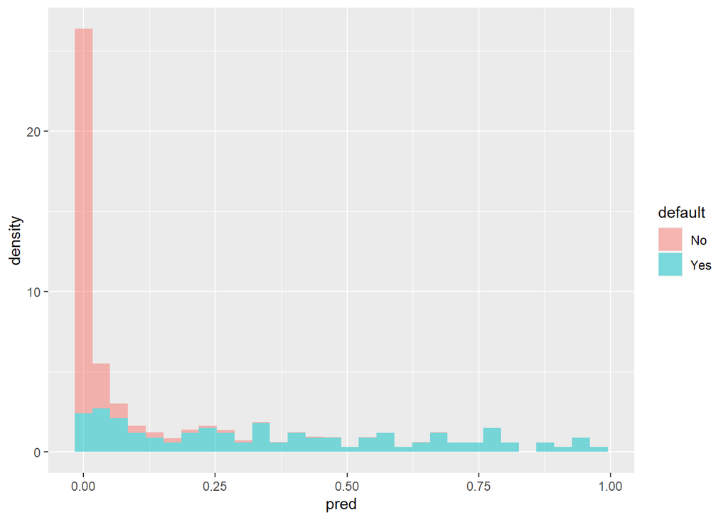

```r
# Histograma ¿Les parece que el modelo es bueno prediciendo el default?
ggplot(default_test)+
  geom_histogram(aes(y=..density.., x=pred,fill=default), alpha=0.5)
```

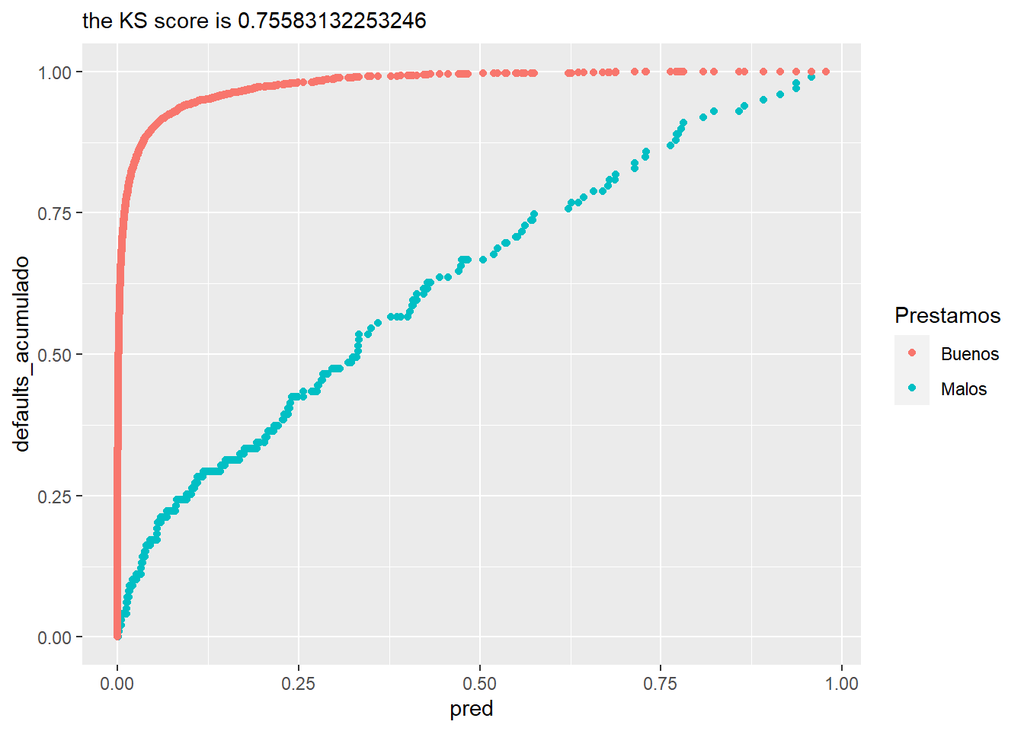

```r
# Komolorov Smirnoff test: Pongamosle un numero a ese performance
default_test<-default_test %>%
  arrange(pred) %>%
  mutate(pagos_acumulado = cumsum(1-bdefault) /
           (nrow(default_test)-sum(default_test$bdefault)),

         defaults_acumulado=cumsum(bdefault)/sum(default_test$bdefault),

         diff=abs(pagos_acumulado-defaults_acumulado))

default_test%>%
  ggplot(aes(x=pred))+
  geom_point(aes(y=defaults_acumulado, color="Malos"))+
  geom_point(aes(y=pagos_acumulado, color="Buenos"))+
  labs(subtitle = paste0("the KS score is ", max(default_test$diff)),
       colour="Prestamos")
```

```r
# Otra manera de medirlo: Curva ROC - Precission vs Recall
# ROC-curve using pROC library
roc_score = roc(default_test$bdefault, default_test$pred)  # AUC score
roc_score
```

```
##
## Call:
## roc.default(response = default_test$bdefault, predictor = default_test$pred)
##
## Data: default_test$pred in 2901 controls (default_test$bdefault 0) < 99 cases (default_test$bdefault 1).
## Area under the curve: 0.947
```

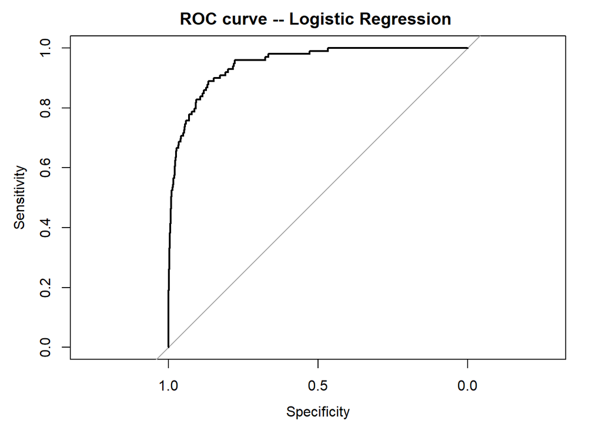

```r
plot(roc_score, main="ROC curve -- Logistic Regression ")
```

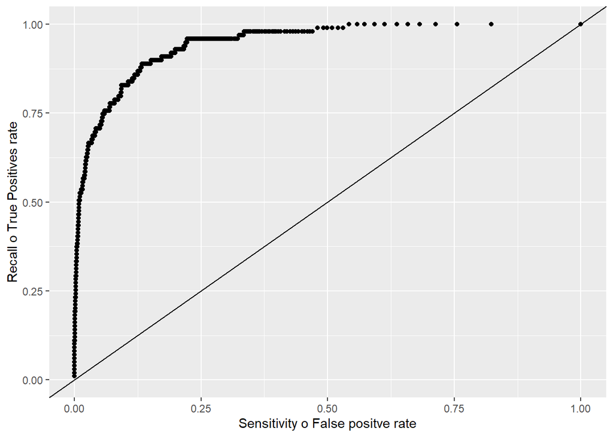

```r
# ROC-curve a manopla
recall_TPR<-c()
FPR<-c()

for (i in seq(0.000010 , 0.9776, by=0.00010 )){

  default_test$default_pred = default_test$pred > i

  # Recall or True Positive Rate (TPR): Cuantos de los defaults pudimos recuperar

  recalled_defaults<-nrow(subset(default_test, default_pred==1& bdefault==1))
  defaults<-nrow(subset(default_test, bdefault==1))

  recall_TPR[i*1/0.000010]<-recalled_defaults/defaults

  # False positive rate
  false_defaults<-nrow(subset(default_test, default_pred==1&  bdefault==0))
  non_defaults<-nrow(subset(default_test, bdefault==0))

  FPR[i*1/0.000010]<-false_defaults/non_defaults

}

ggplot(data=data.frame(FPR, recall_TPR),
       aes(x=FPR,y=recall_TPR))+
  geom_point()+
  geom_abline(slope = 1)+
  scale_y_continuous(limits=c(0,1))+
  scale_x_continuous(limits=c(0,1))+
  labs(y="Recall o True Positives rate",
       x="Sensitivity o False positve rate")
```

Y eso es todo, ya puedes poner que sabes un poco de credit scoring en el CV (quizás lo sabías hacer desde hace tiempo y no te habías dado cuenta, , cómo me paso a mi.)